# MEDBS datacall Report

Compiled on 08/01/2026, 15:24

No catch data available

No Landing data available

No Discard data available

No growth parameters (GP) data available

No Maturity at Age (MA) data available

No Maturity at Length (ML) data available

No Sex Ratio at age (SRA) data available

No Sex Ratio at length (SRL) data available

# 1 Age-Length Keys (ALK) table

## 1.1 Presence of duplicated records

Data included in the ALK table were checked for the presence of duplicated records. The results of the check are here reported:

- No replicated records in ALK data

*Attention*: eventual duplicated records will be removed from ALK data for the following analysis

## 1.2 Plots of Age-Length Keys (ALK) data

### 1.2.1 GSA 18

#### 1.2.1.1 ANE

Plot of ALK for ANE - ITA - GSA 18 - Combined

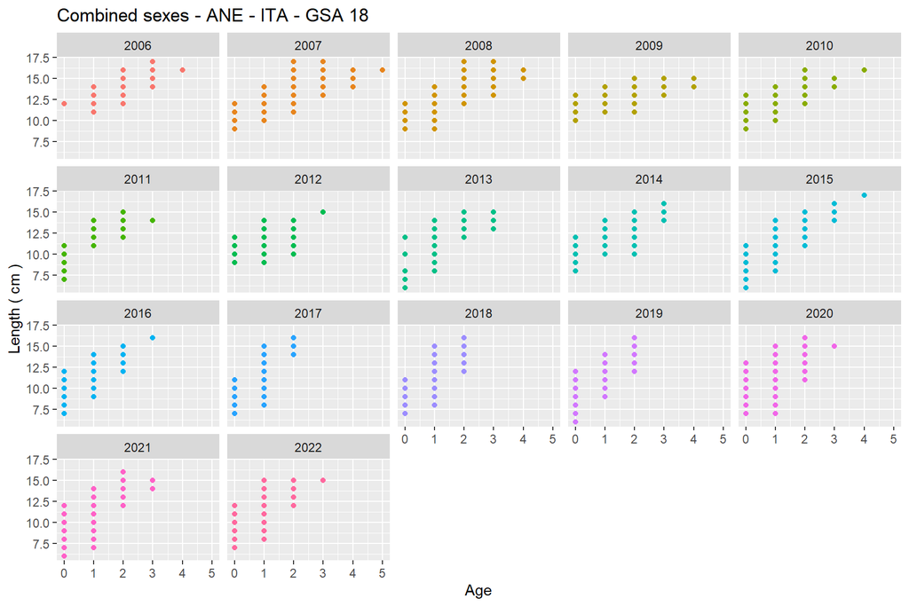

#### 1.2.1.2 PIL

Plot of ALK for PIL - ITA - GSA 18 - Combined

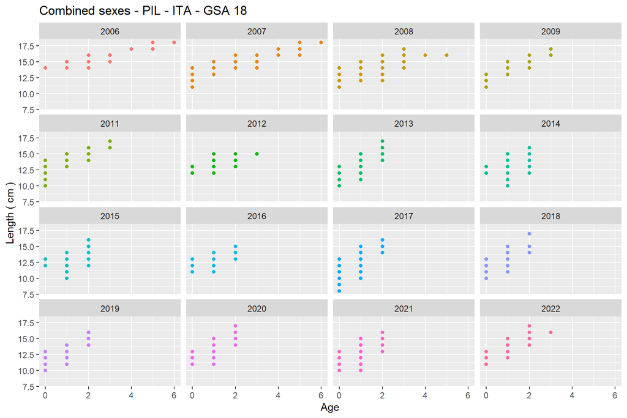

#### 1.2.1.3 TUR

#### 1.2.1.4 SPR

#### 1.2.1.5 HMM

Plot of ALK for HMM - ITA - GSA 18 - Combined

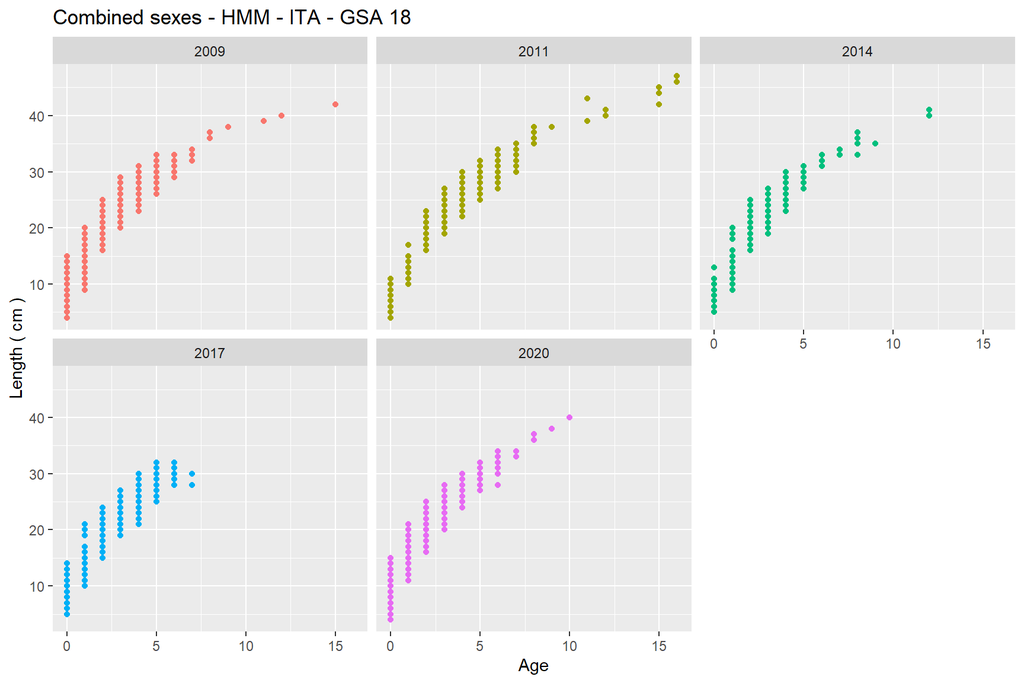

#### 1.2.1.6 MUT

Plot of ALK for MUT - ITA - GSA 18 - Females

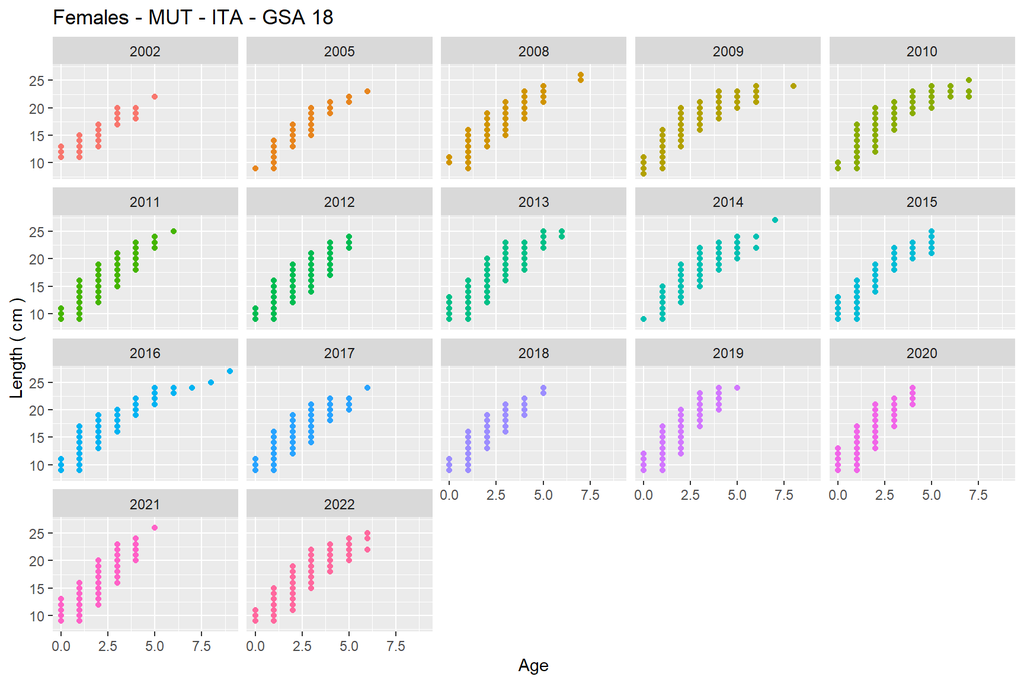

Plot of ALK for MUT - ITA - GSA 18 - Males

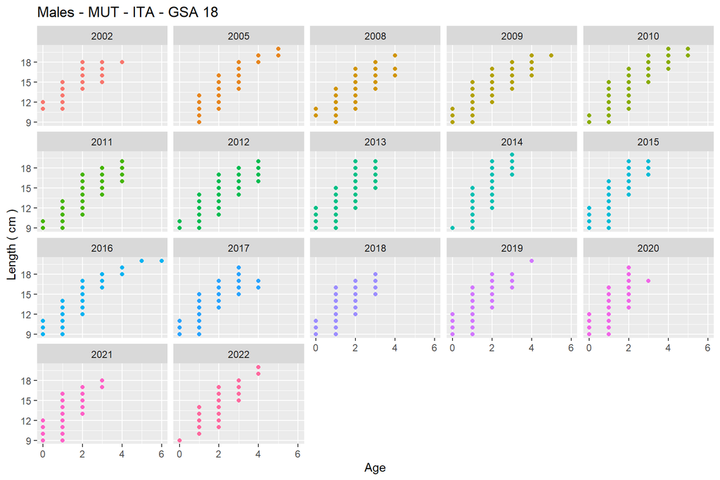

Plot of ALK for MUT - ITA - GSA 18 - Combined

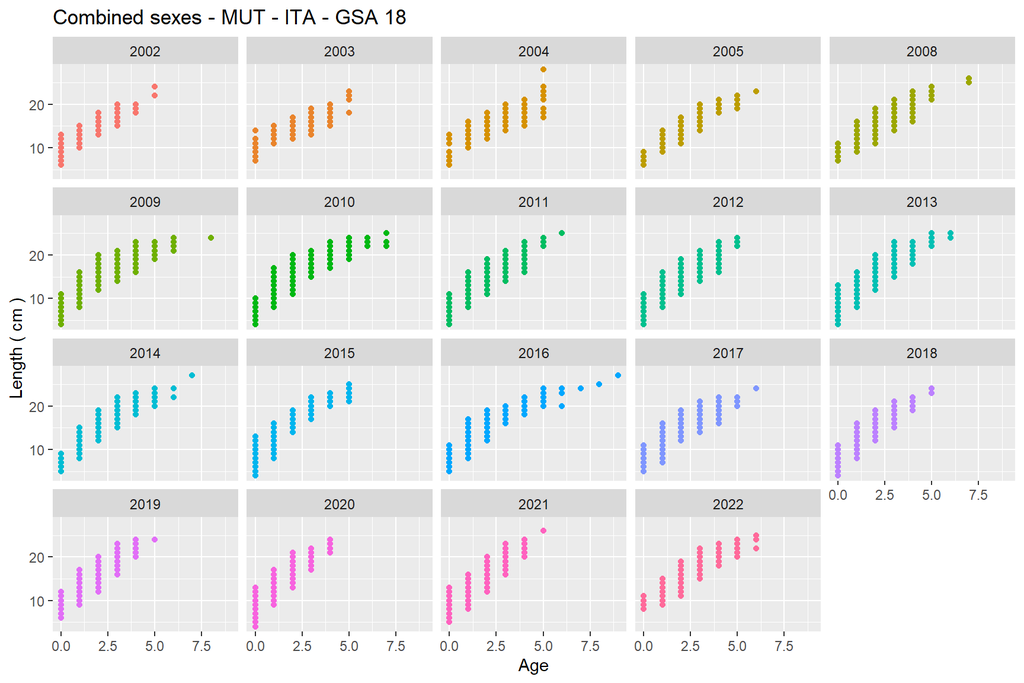

#### 1.2.1.7 WHG

#### 1.2.1.8 MUR

Plot of ALK for MUR - ITA - GSA 18 - Combined

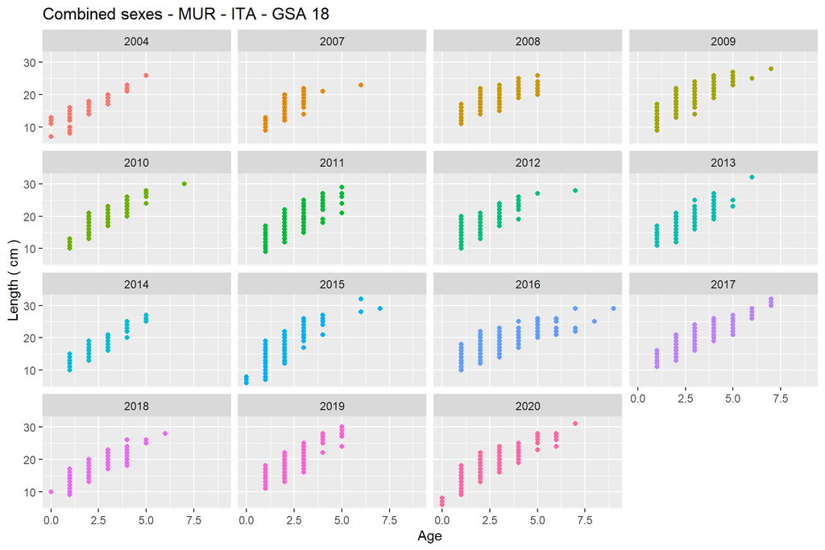

#### 1.2.1.9 HKE

Plot of ALK for HKE - ITA - GSA 18 - Females

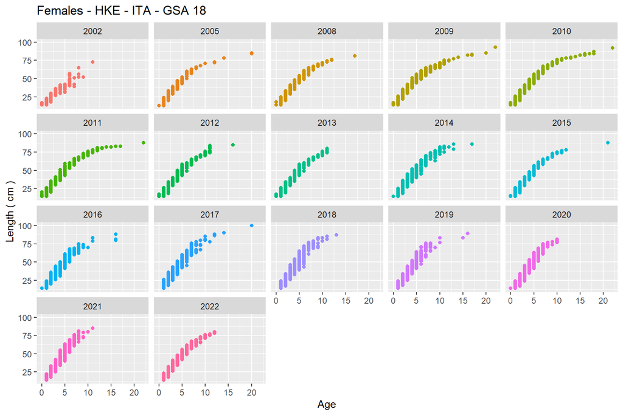

Plot of ALK for HKE - ITA - GSA 18 - Males

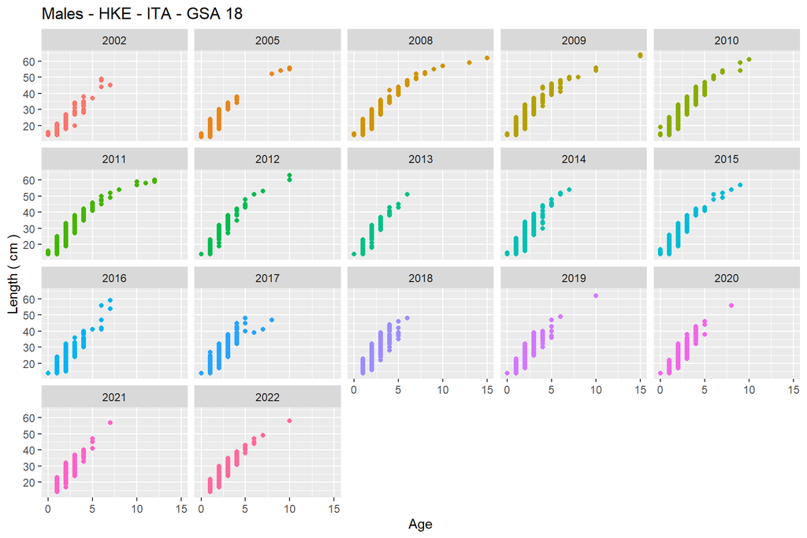

Plot of ALK for HKE - ITA - GSA 18 - Combined

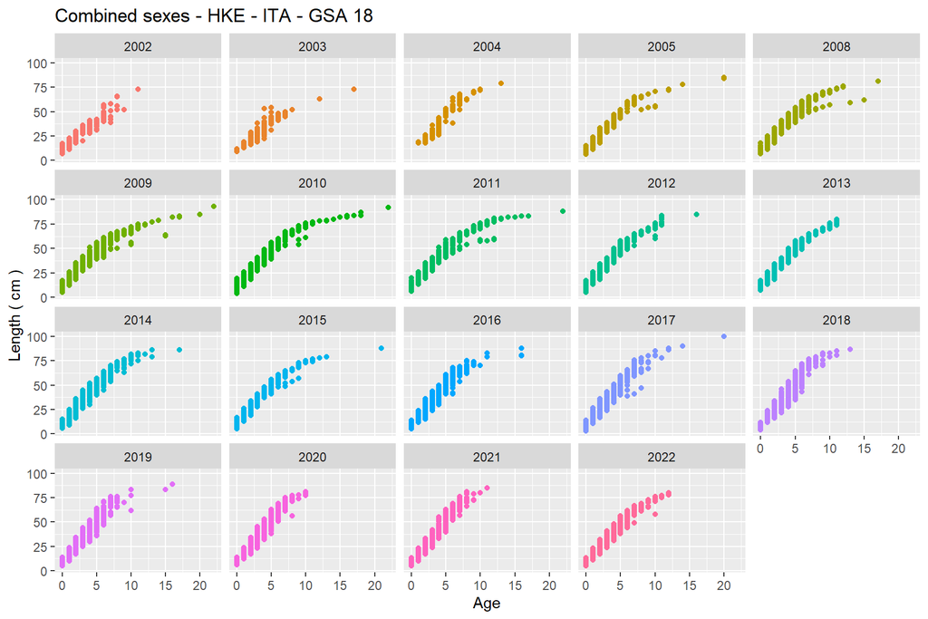

#### 1.2.1.10 BOG

Plot of ALK for BOG - ITA - GSA 18 - Combined

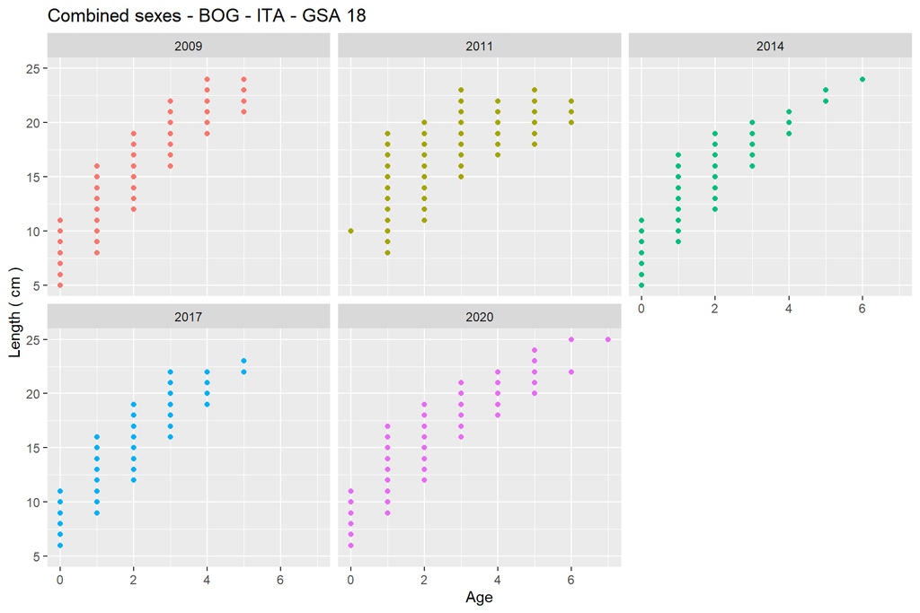

#### 1.2.1.11 HOM

Plot of ALK for HOM - ITA - GSA 18 - Combined

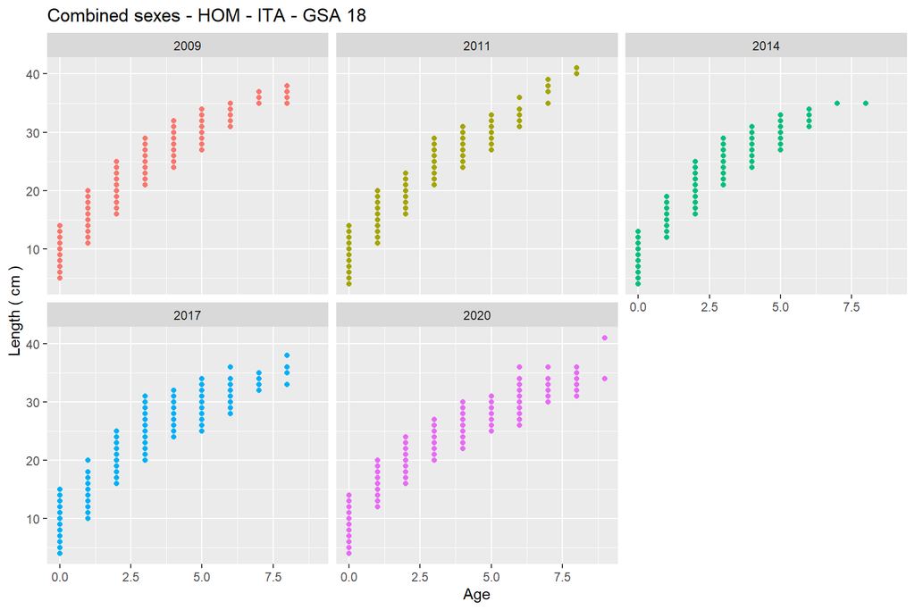

#### 1.2.1.12 WHB

Plot of ALK for WHB - ITA - GSA 18 - Combined

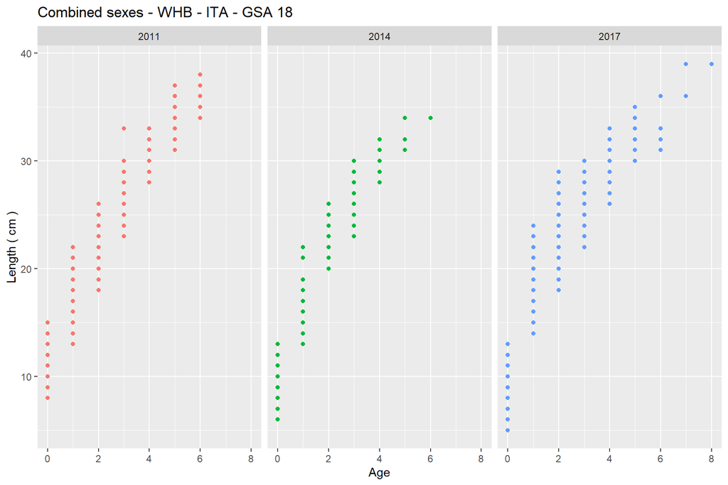

#### 1.2.1.13 PAC

Plot of ALK for PAC - ITA - GSA 18 - Combined

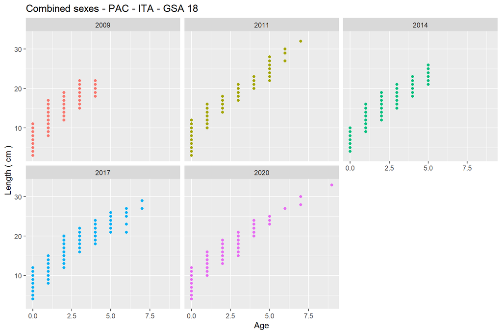

#### 1.2.1.14 MAC

#### 1.2.1.15 MAS

#### 1.2.1.16 SAA

#### 1.2.1.17 RJC

Plot of ALK for RJC - ITA - GSA 18 - Combined

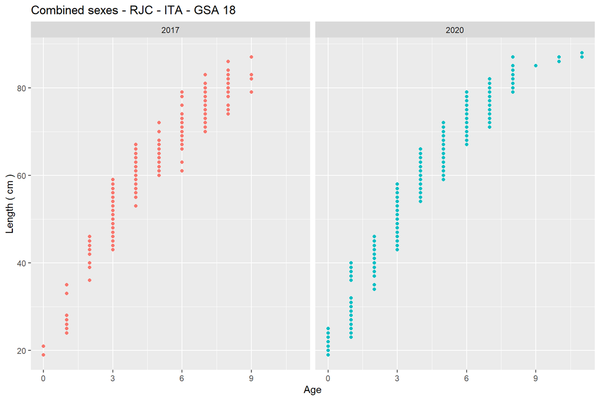

#### 1.2.1.18 VMA

Plot of ALK for VMA - ITA - GSA 18 - Combined

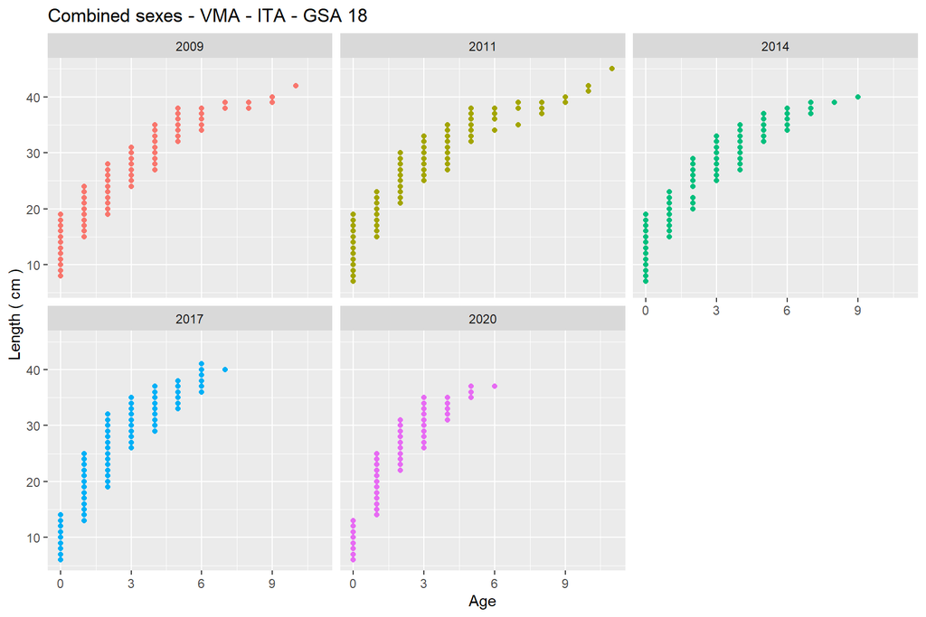

#### 1.2.1.19 SBR

#### 1.2.1.20 DOL

#### 1.2.1.21 SOL

Plot of ALK for SOL - ITA - GSA 18 - Combined

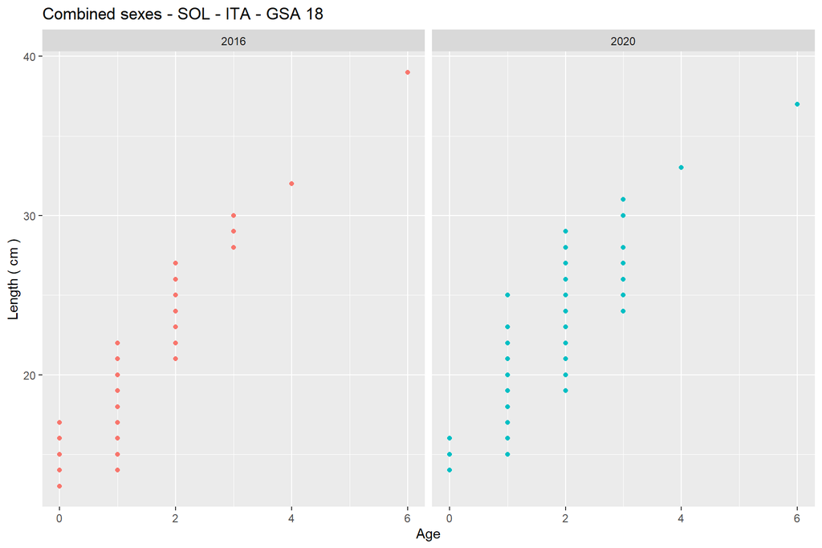

#### 1.2.1.22 SBG

#### 1.2.1.23 BSS

#### 1.2.1.24 MON

#### 1.2.1.25 ANK

Plot of ALK for ANK - ITA - GSA 18 - Females

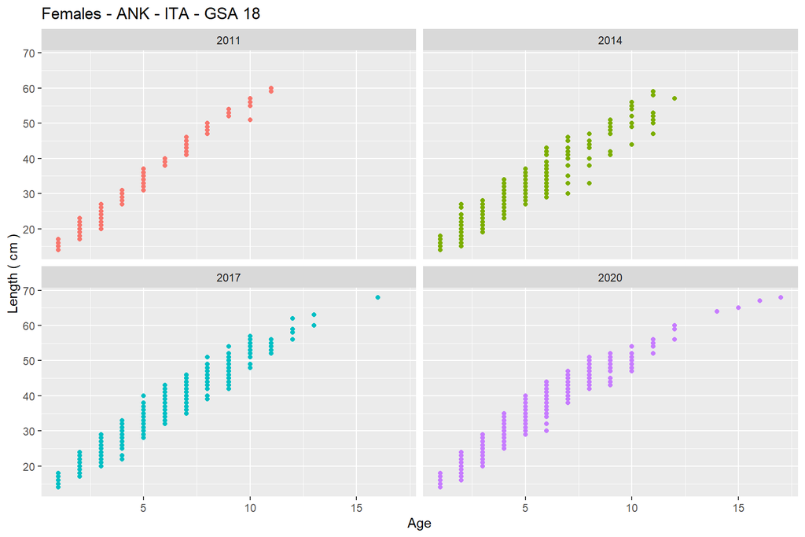

Plot of ALK for ANK - ITA - GSA 18 - Males

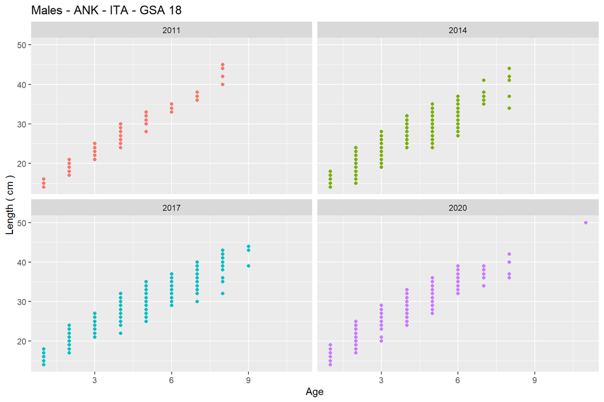

Plot of ALK for ANK - ITA - GSA 18 - Combined

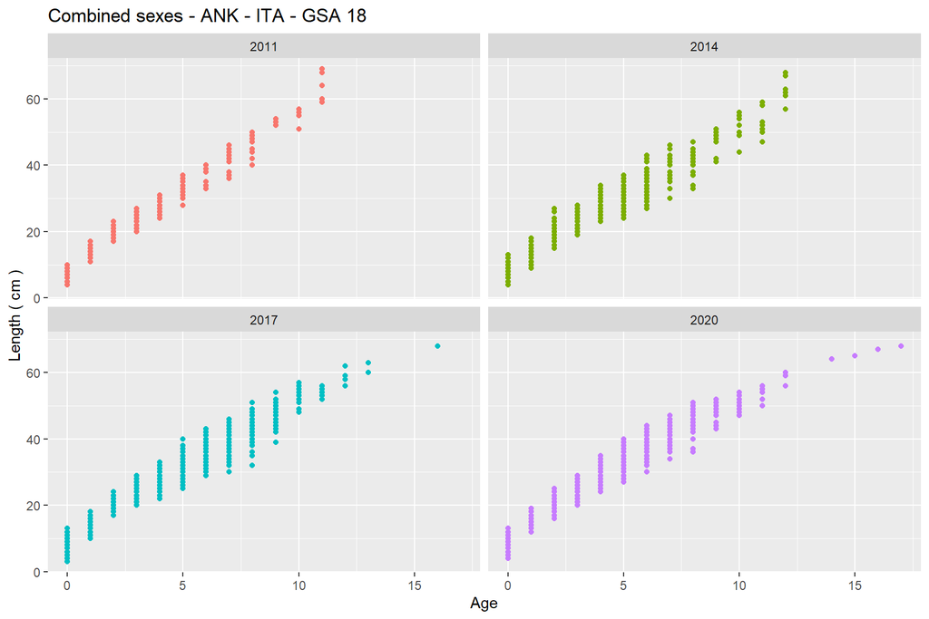

#### 1.2.1.26 BON

#### 1.2.1.27 SPC

Plot of ALK for SPC - ITA - GSA 18 - Combined

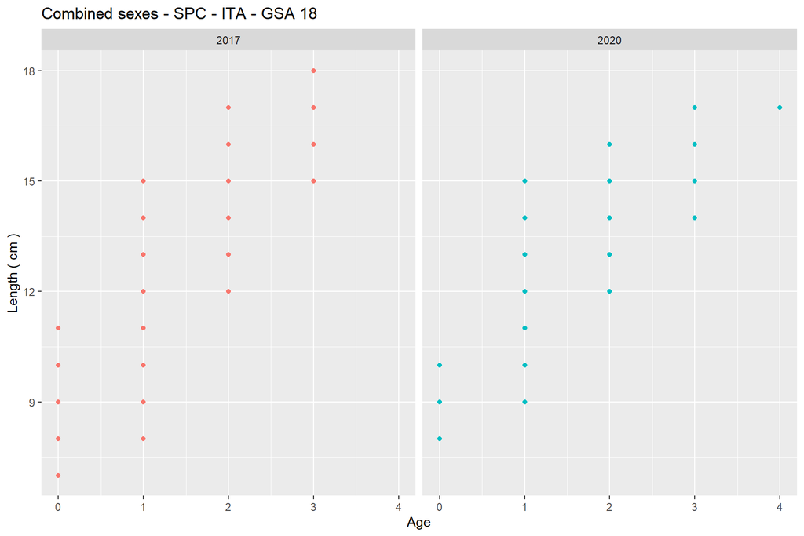

#### 1.2.1.28 YRS

#### 1.2.1.29 GFB

#### 1.2.1.30 GUR

#### 1.2.1.31 GUU

Plot of ALK for GUU - ITA - GSA 18 - Females

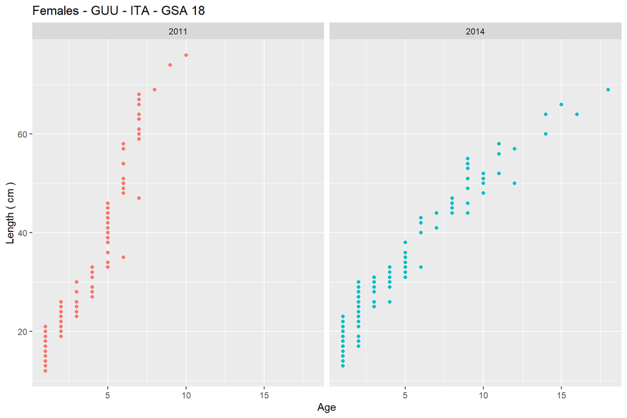

Plot of ALK for GUU - ITA - GSA 18 - Males

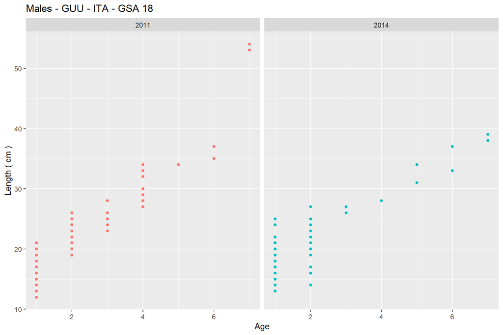

Plot of ALK for GUU - ITA - GSA 18 - Combined

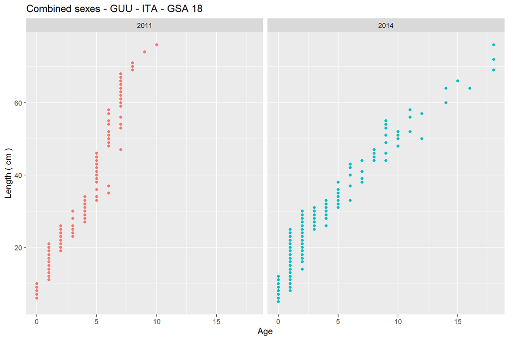

#### 1.2.1.32 MAZ

#### 1.2.1.33 SVE

#### 1.2.1.34 GUG

Plot of ALK for GUG - ITA - GSA 18 - Combined

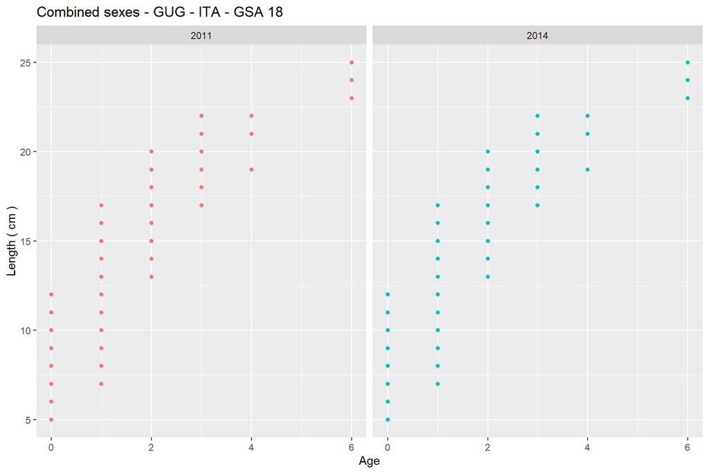

## 1.3 Plots of mean length at age from the Age-Length Keys (ALK) data

### 1.3.1 GSA 18

#### 1.3.1.1 ANE

$`Combined - ANE - ITA - GSA 18`

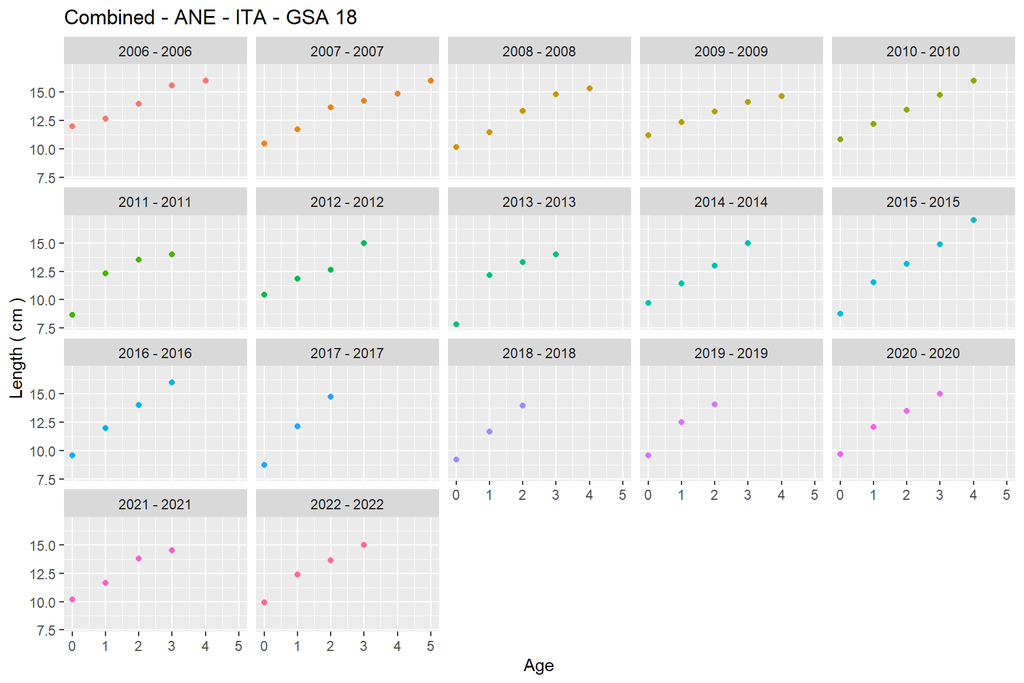

#### 1.3.1.2 PIL

$`Combined - PIL - ITA - GSA 18`

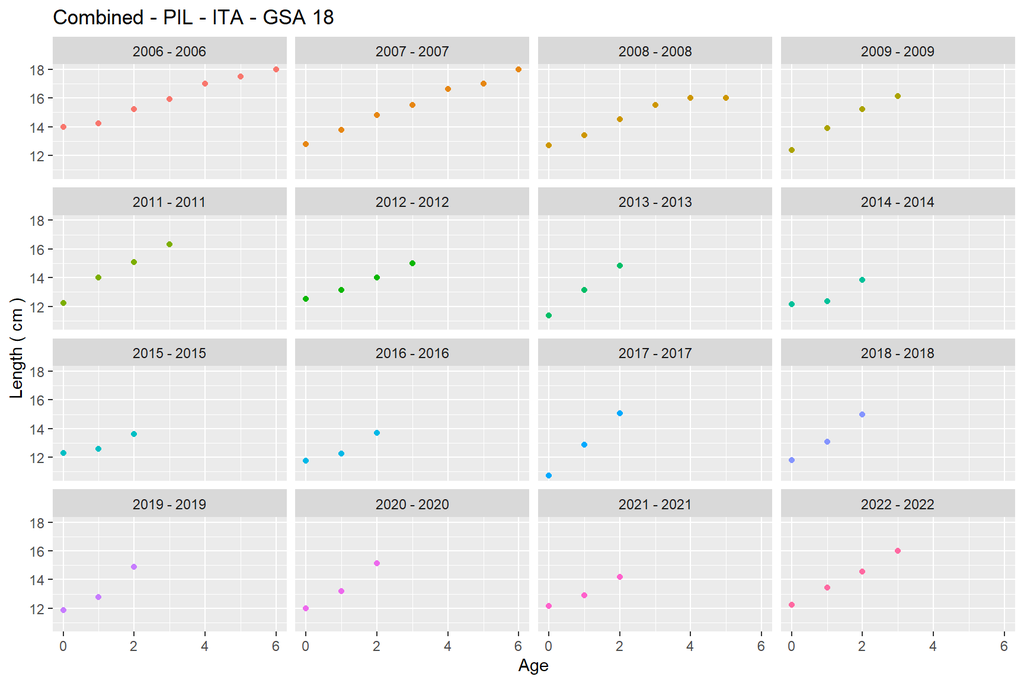

#### 1.3.1.3 TUR

- No ALK data are available for the selected combination: TUR - ITA - GSA 18.

#### 1.3.1.4 SPR

- No ALK data are available for the selected combination: SPR - ITA - GSA 18.

#### 1.3.1.5 HMM

$`Combined - HMM - ITA - GSA 18`

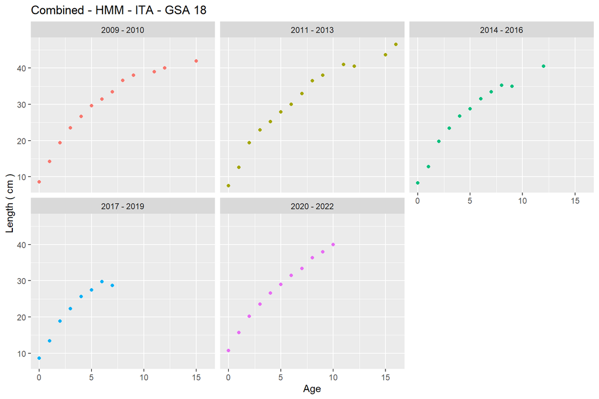

#### 1.3.1.6 MUT

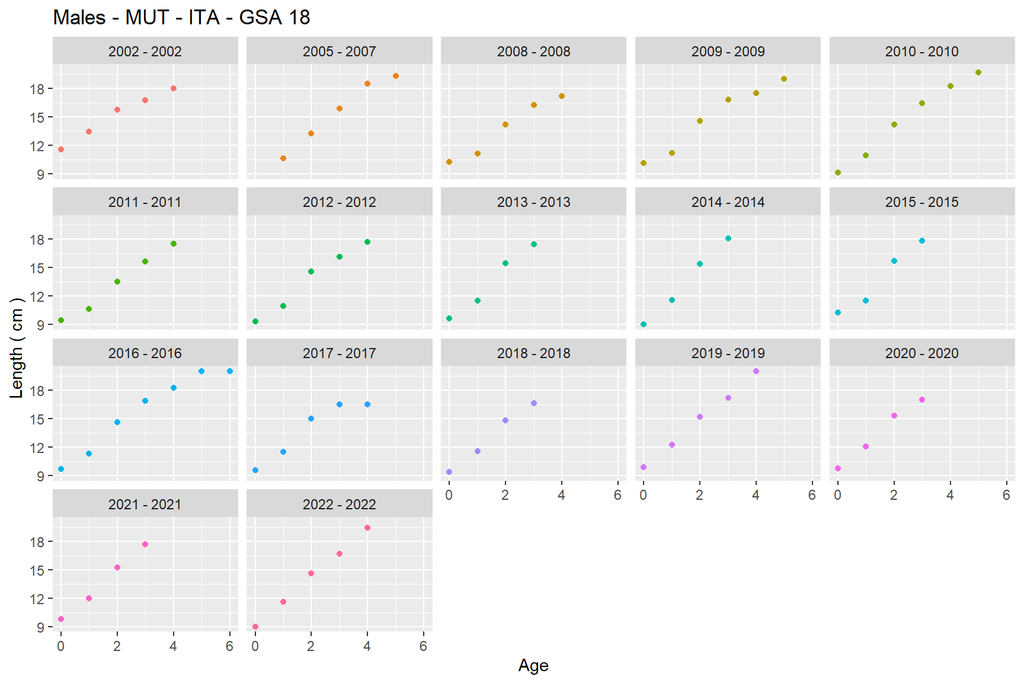

$`Combined - MUT - ITA - GSA 18`

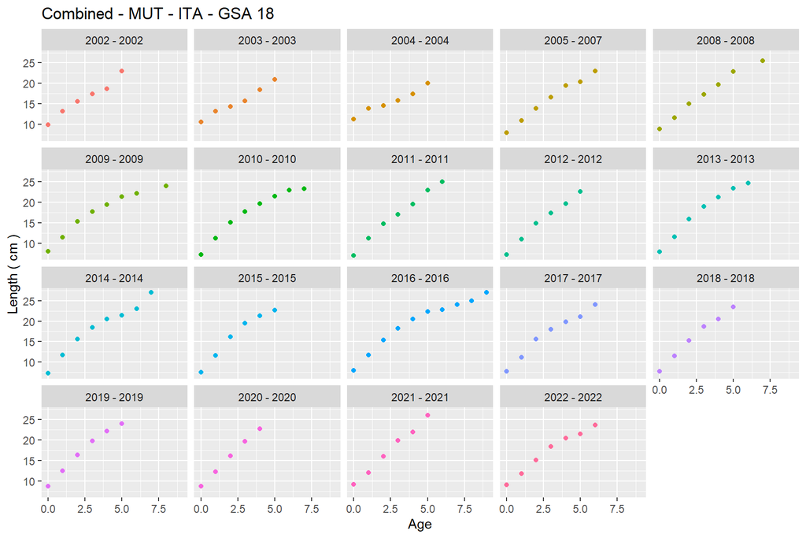

#### 1.3.1.7 WHG

- No ALK data are available for the selected combination: WHG - ITA - GSA 18.

#### 1.3.1.8 MUR

$`Combined - MUR - ITA - GSA 18`

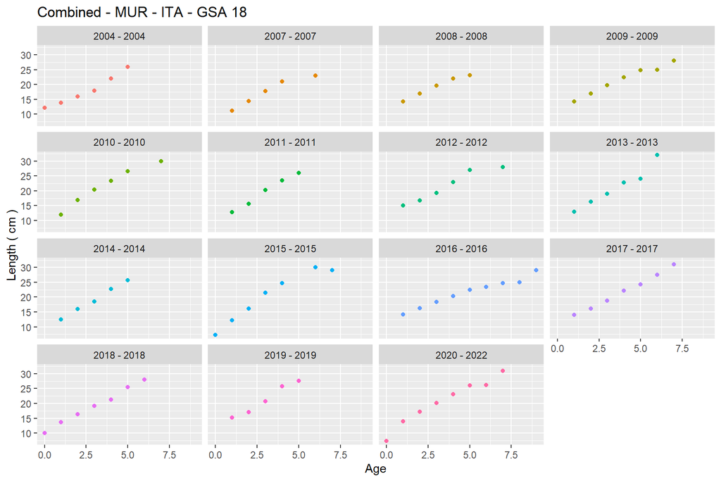

#### 1.3.1.9 HKE

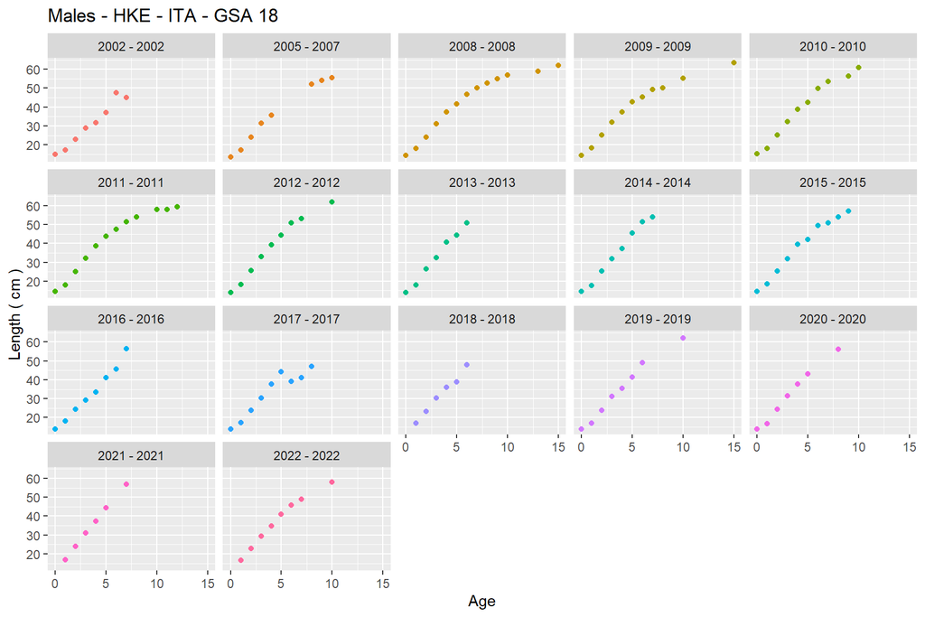

$`Combined - HKE - ITA - GSA 18`

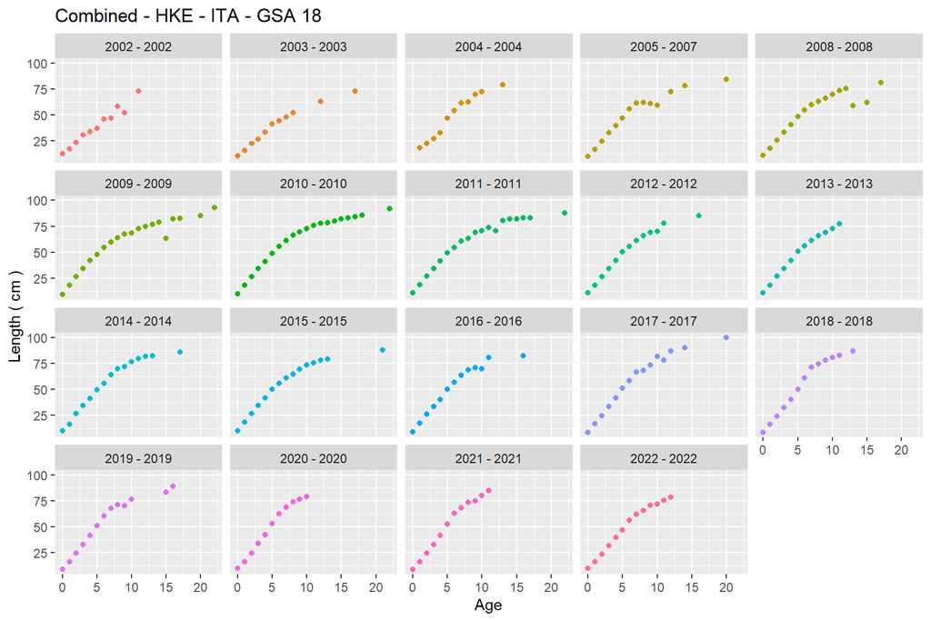

#### 1.3.1.10 BOG

$`Combined - BOG - ITA - GSA 18`

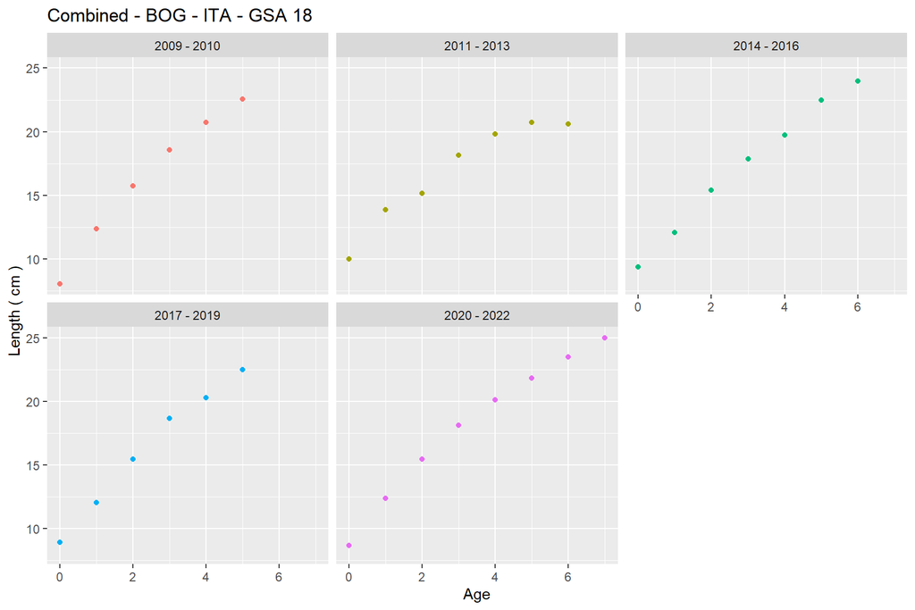

#### 1.3.1.11 HOM

$`Combined - HOM - ITA - GSA 18`

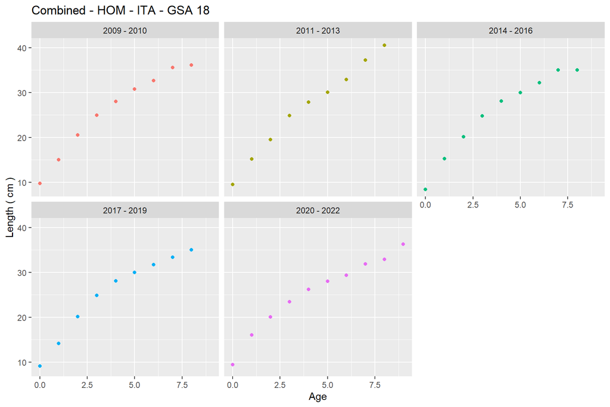

#### 1.3.1.12 WHB

$`Combined - WHB - ITA - GSA 18`

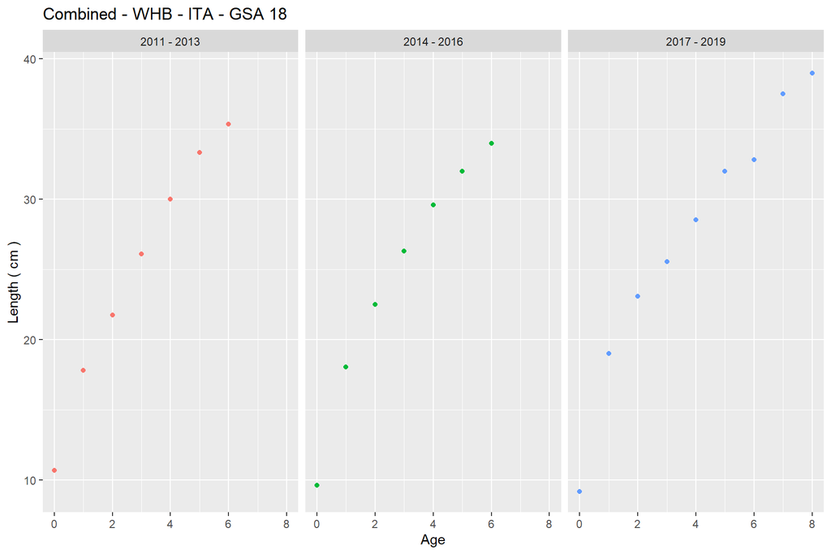

#### 1.3.1.13 PAC

$`Combined - PAC - ITA - GSA 18`

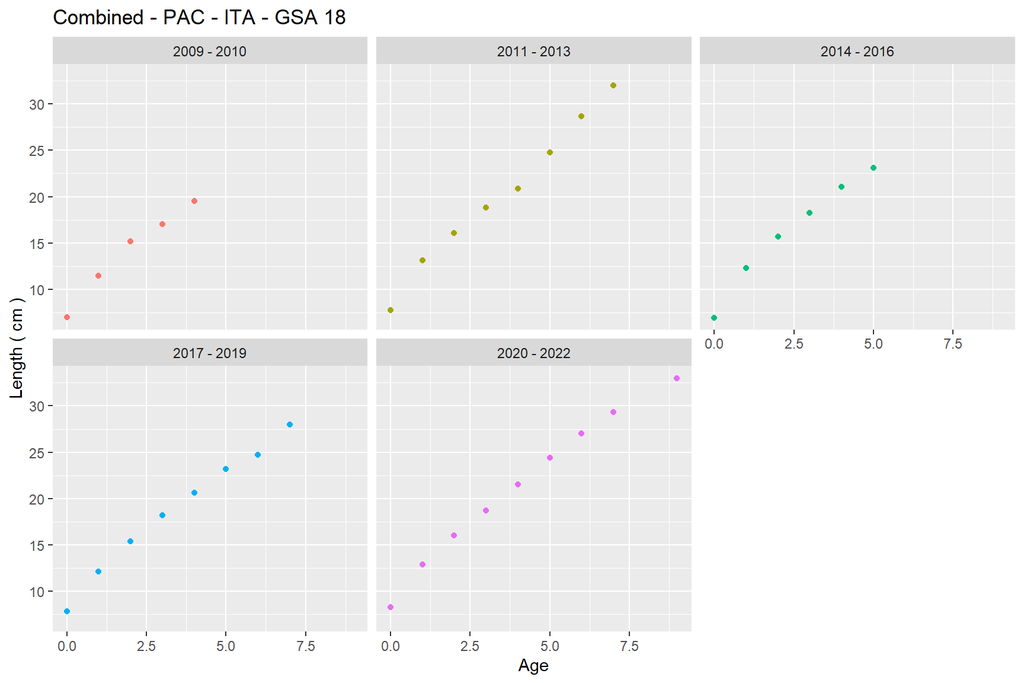

#### 1.3.1.14 MAC

- No ALK data are available for the selected combination: MAC - ITA - GSA 18.

#### 1.3.1.15 MAS

- No ALK data are available for the selected combination: MAS - ITA - GSA 18.

#### 1.3.1.16 SAA

- No ALK data are available for the selected combination: SAA - ITA - GSA 18.

#### 1.3.1.17 RJC

$`Combined - RJC - ITA - GSA 18`

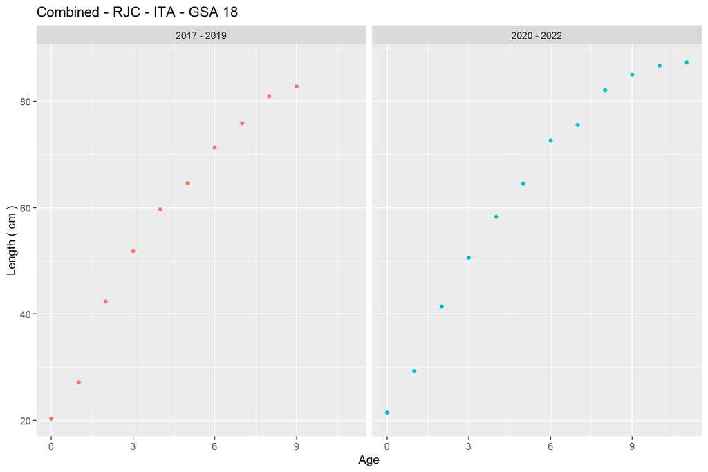

#### 1.3.1.18 VMA

$`Combined - VMA - ITA - GSA 18`

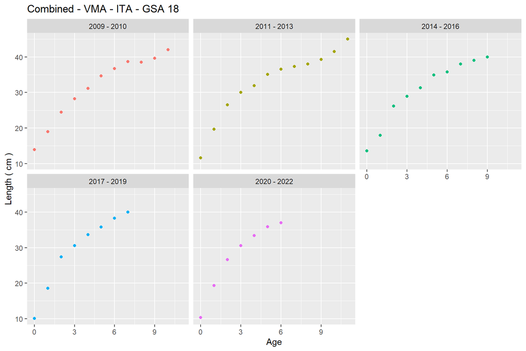

#### 1.3.1.19 SBR

- No ALK data are available for the selected combination: SBR - ITA - GSA 18.

#### 1.3.1.20 DOL

- No ALK data are available for the selected combination: DOL - ITA - GSA 18.

#### 1.3.1.21 SOL

$`Combined - SOL - ITA - GSA 18`

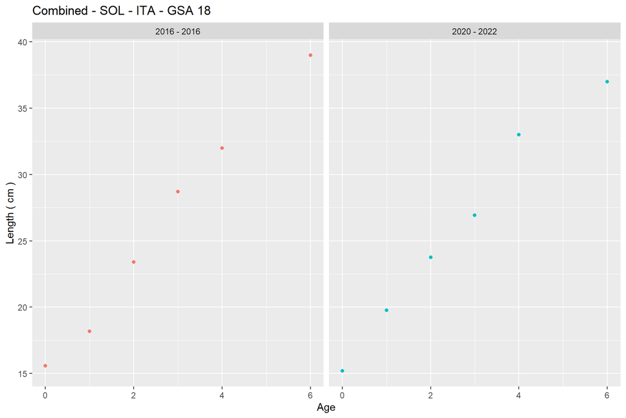

#### 1.3.1.22 SBG

- No ALK data are available for the selected combination: SBG - ITA - GSA 18.

#### 1.3.1.23 BSS

- No ALK data are available for the selected combination: BSS - ITA - GSA 18.

#### 1.3.1.24 MON

- No ALK data are available for the selected combination: MON - ITA - GSA 18.

#### 1.3.1.25 ANK

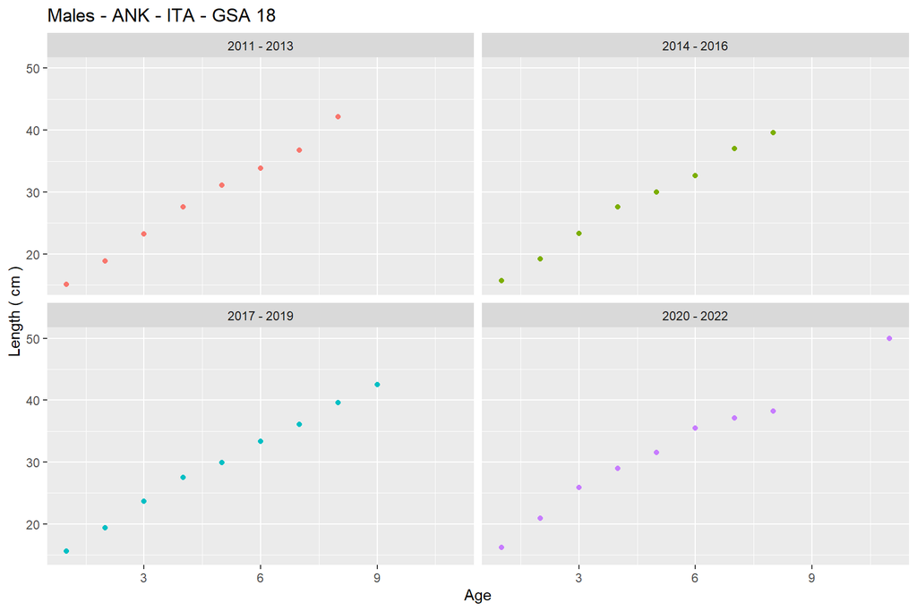

$`Combined - ANK - ITA - GSA 18`

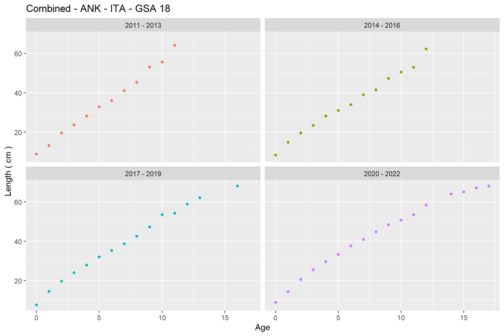

#### 1.3.1.26 BON

- No ALK data are available for the selected combination: BON - ITA - GSA 18.

#### 1.3.1.27 SPC

$`Combined - SPC - ITA - GSA 18`

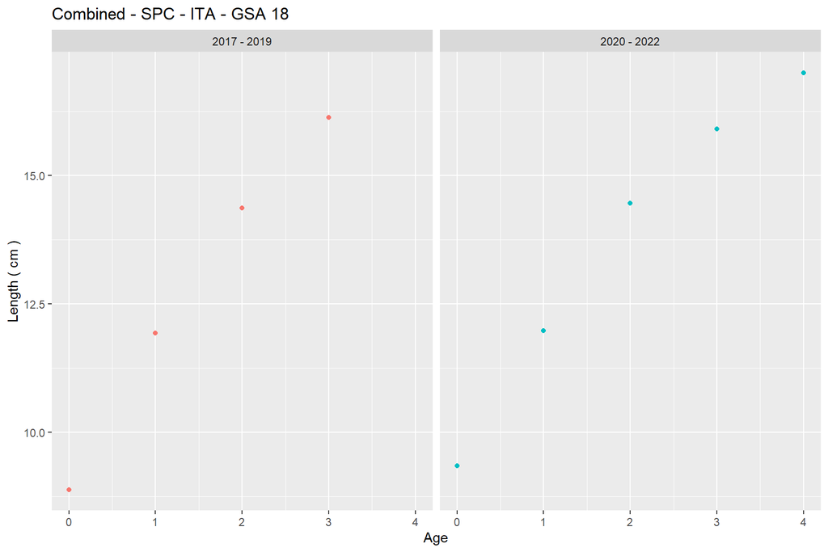

#### 1.3.1.28 YRS

- No ALK data are available for the selected combination: YRS - ITA - GSA 18.

#### 1.3.1.29 GFB

- No ALK data are available for the selected combination: GFB - ITA - GSA 18.

#### 1.3.1.30 GUR

- No ALK data are available for the selected combination: GUR - ITA - GSA 18.

#### 1.3.1.31 GUU

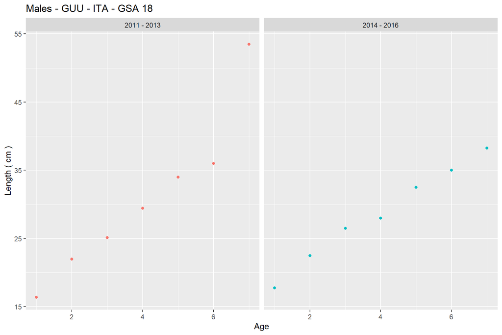

$`Combined - GUU - ITA - GSA 18`

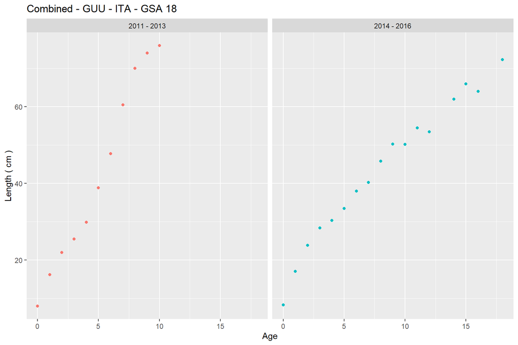

#### 1.3.1.32 MAZ

- No ALK data are available for the selected combination: MAZ - ITA - GSA 18.

#### 1.3.1.33 SVE

- No ALK data are available for the selected combination: SVE - ITA - GSA 18.

#### 1.3.1.34 GUG

$`Combined - GUG - ITA - GSA 18`

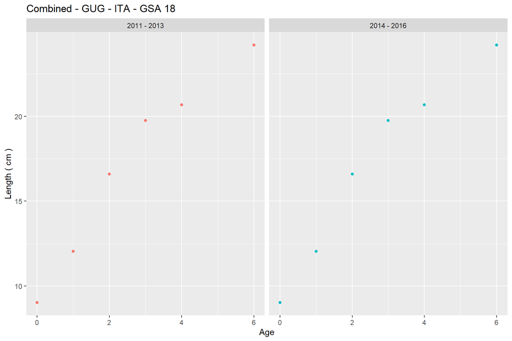

## 1.4 Check if the total number of hard structures is consistent with the sum of numbers by age in the Age-Length Keys (ALK) data

### 1.4.1 GSA 18

#### 1.4.1.1 ANE

Records for which the total number of hard structures is not consistent with the sum of numbers by age from ALK for ANE - ITA - GSA 18 -

| START_YEAR | END_YEAR | SEX | AREA | TOTAL_NUMBER_OF_HARD_STRUCTURE_READ_BY_AGE | total_n | diff |
| --- | --- | --- | --- | --- | --- | --- |
| 2006 | 2006 | C | GSA 18 | 1 | 2 | -1 |
| 2012 | 2012 | C | GSA 18 | 70 | 140 | -70 |

#### 1.4.1.2 PIL

- All records are consistent for the selected combination: PIL - ITA - GSA 18.

#### 1.4.1.3 TUR

- No ALK data are available for the selected combination: TUR - ITA - GSA 18.

#### 1.4.1.4 SPR

- No ALK data are available for the selected combination: SPR - ITA - GSA 18.

#### 1.4.1.5 HMM

Records for which the total number of hard structures is not consistent with the sum of numbers by age from ALK for HMM - ITA - GSA 18 -

| START_YEAR | END_YEAR | SEX | AREA | TOTAL_NUMBER_OF_HARD_STRUCTURE_READ_BY_AGE | total_n | diff |
| --- | --- | --- | --- | --- | --- | --- |
| 2009 | 2010 | C | GSA 18 | 1 | 3 | -2 |
| 2009 | 2010 | C | GSA 18 | 241 | 482 | -241 |
| 2011 | 2013 | C | GSA 18 | 2 | 6 | -4 |
| 2014 | 2016 | C | GSA 18 | 2 | 4 | -2 |
| 2020 | 2022 | C | GSA 18 | 1 | 2 | -1 |
| 2020 | 2022 | C | GSA 18 | 3 | 6 | -3 |

#### 1.4.1.6 MUT

Records for which the total number of hard structures is not consistent with the sum of numbers by age from ALK for MUT - ITA - GSA 18 -

| START_YEAR | END_YEAR | SEX | AREA | TOTAL_NUMBER_OF_HARD_STRUCTURE_READ_BY_AGE | total_n | diff |
| --- | --- | --- | --- | --- | --- | --- |
| 2008 | 2008 | F | GSA 18 | 8 | 16 | -8 |
| 2010 | 2010 | C | GSA 18 | 138 | 276 | -138 |
| 2016 | 2016 | C | GSA 18 | 1 | 2 | -1 |
| 2016 | 2016 | F | GSA 18 | 1 | 2 | -1 |
| 2016 | 2016 | M | GSA 18 | 1 | 2 | -1 |
| 2022 | 2022 | F | GSA 18 | 83 | 166 | -83 |

#### 1.4.1.7 WHG

- No ALK data are available for the selected combination: WHG - ITA - GSA 18.

#### 1.4.1.8 MUR

Records for which the total number of hard structures is not consistent with the sum of numbers by age from ALK for MUR - ITA - GSA 18 -

| START_YEAR | END_YEAR | SEX | AREA | TOTAL_NUMBER_OF_HARD_STRUCTURE_READ_BY_AGE | total_n | diff |
| --- | --- | --- | --- | --- | --- | --- |
| 2004 | 2004 | C | GSA 18 | 50 | 100 | -50 |
| 2012 | 2012 | C | GSA 18 | 1 | 2 | -1 |
| 2016 | 2016 | C | GSA 18 | 1 | 2 | -1 |
| 2018 | 2018 | C | GSA 18 | 1 | 2 | -1 |

#### 1.4.1.9 HKE

Records for which the total number of hard structures is not consistent with the sum of numbers by age from ALK for HKE - ITA - GSA 18 -

| START_YEAR | END_YEAR | SEX | AREA | TOTAL_NUMBER_OF_HARD_STRUCTURE_READ_BY_AGE | total_n | diff |
| --- | --- | --- | --- | --- | --- | --- |
| 2002 | 2002 | C | GSA 18 | 1 | 2 | -1 |
| 2002 | 2002 | C | GSA 18 | 5 | 10 | -5 |
| 2002 | 2002 | F | GSA 18 | 1 | 2 | -1 |
| 2003 | 2003 | C | GSA 18 | 1 | 3 | -2 |
| 2003 | 2003 | C | GSA 18 | 5 | 10 | -5 |
| 2004 | 2004 | C | GSA 18 | 2 | 4 | -2 |
| 2004 | 2004 | C | GSA 18 | 13 | 26 | -13 |
| 2005 | 2007 | C | GSA 18 | 2 | 8 | -6 |
| 2005 | 2007 | C | GSA 18 | 4 | 8 | -4 |
| 2005 | 2007 | F | GSA 18 | 1 | 2 | -1 |
| 2005 | 2007 | F | GSA 18 | 2 | 8 | -6 |
| 2005 | 2007 | M | GSA 18 | 1 | 2 | -1 |
| 2008 | 2008 | C | GSA 18 | 1 | 3 | -2 |
| 2008 | 2008 | C | GSA 18 | 301 | 602 | -301 |
| 2008 | 2008 | M | GSA 18 | 1 | 3 | -2 |
| 2009 | 2009 | C | GSA 18 | 1 | 4 | -3 |
| 2009 | 2009 | C | GSA 18 | 2 | 4 | -2 |
| 2009 | 2009 | F | GSA 18 | 1 | 4 | -3 |
| 2009 | 2009 | M | GSA 18 | 28 | 56 | -28 |
| 2010 | 2010 | C | GSA 18 | 1 | 4 | -3 |
| 2010 | 2010 | C | GSA 18 | 2 | 6 | -4 |
| 2010 | 2010 | F | GSA 18 | 1 | 4 | -3 |
| 2010 | 2010 | F | GSA 18 | 2 | 6 | -4 |
| 2010 | 2010 | F | GSA 18 | 10 | 20 | -10 |
| 2010 | 2010 | F | GSA 18 | 90 | 180 | -90 |
| 2010 | 2010 | M | GSA 18 | 2 | 4 | -2 |
| 2010 | 2010 | M | GSA 18 | 6 | 12 | -6 |
| 2011 | 2011 | C | GSA 18 | 1 | 4 | -3 |
| 2011 | 2011 | C | GSA 18 | 2 | 4 | -2 |
| 2011 | 2011 | C | GSA 18 | 7 | 14 | -7 |
| 2011 | 2011 | F | GSA 18 | 1 | 4 | -3 |
| 2011 | 2011 | F | GSA 18 | 2 | 4 | -2 |
| 2012 | 2012 | M | GSA 18 | 1 | 2 | -1 |
| 2012 | 2012 | M | GSA 18 | 7 | 14 | -7 |
| 2013 | 2013 | F | GSA 18 | 15 | 30 | -15 |
| 2014 | 2014 | C | GSA 18 | 1 | 2 | -1 |
| 2014 | 2014 | F | GSA 18 | 1 | 2 | -1 |
| 2014 | 2014 | F | GSA 18 | 2 | 4 | -2 |
| 2015 | 2015 | C | GSA 18 | 1 | 3 | -2 |
| 2015 | 2015 | F | GSA 18 | 1 | 2 | -1 |
| 2015 | 2015 | M | GSA 18 | 1 | 2 | -1 |
| 2015 | 2015 | M | GSA 18 | 3 | 6 | -3 |
| 2016 | 2016 | F | GSA 18 | 4 | 8 | -4 |
| 2016 | 2016 | M | GSA 18 | 5 | 10 | -5 |
| 2017 | 2017 | C | GSA 18 | 1 | 3 | -2 |
| 2017 | 2017 | F | GSA 18 | 1 | 3 | -2 |
| 2017 | 2017 | M | GSA 18 | 1 | 4 | -3 |
| 2018 | 2018 | C | GSA 18 | 2 | 4 | -2 |
| 2018 | 2018 | C | GSA 18 | 320 | 640 | -320 |
| 2018 | 2018 | F | GSA 18 | 2 | 4 | -2 |
| 2019 | 2019 | C | GSA 18 | 1 | 3 | -2 |
| 2019 | 2019 | F | GSA 18 | 1 | 3 | -2 |
| 2019 | 2019 | M | GSA 18 | 1 | 3 | -2 |
| 2020 | 2020 | F | GSA 18 | 121 | 242 | -121 |
| 2020 | 2020 | M | GSA 18 | 1 | 2 | -1 |
| 2021 | 2021 | C | GSA 18 | 3 | 6 | -3 |
| 2021 | 2021 | F | GSA 18 | 3 | 6 | -3 |
| 2022 | 2022 | M | GSA 18 | 1 | 2 | -1 |

#### 1.4.1.10 BOG

- All records are consistent for the selected combination: BOG - ITA - GSA 18.

#### 1.4.1.11 HOM

Records for which the total number of hard structures is not consistent with the sum of numbers by age from ALK for HOM - ITA - GSA 18 -

| START_YEAR | END_YEAR | SEX | AREA | TOTAL_NUMBER_OF_HARD_STRUCTURE_READ_BY_AGE | total_n | diff |
| --- | --- | --- | --- | --- | --- | --- |
| 2014 | 2016 | C | GSA 18 | 1 | 2 | -1 |
| 2020 | 2022 | C | GSA 18 | 151 | 302 | -151 |

#### 1.4.1.12 WHB

- All records are consistent for the selected combination: WHB - ITA - GSA 18.

#### 1.4.1.13 PAC

Records for which the total number of hard structures is not consistent with the sum of numbers by age from ALK for PAC - ITA - GSA 18 -

| START_YEAR | END_YEAR | SEX | AREA | TOTAL_NUMBER_OF_HARD_STRUCTURE_READ_BY_AGE | total_n | diff |
| --- | --- | --- | --- | --- | --- | --- |
| 2020 | 2022 | C | GSA 18 | 1 | 2 | -1 |

#### 1.4.1.14 MAC

- No ALK data are available for the selected combination: MAC - ITA - GSA 18.

#### 1.4.1.15 MAS

- No ALK data are available for the selected combination: MAS - ITA - GSA 18.

#### 1.4.1.16 SAA

- No ALK data are available for the selected combination: SAA - ITA - GSA 18.

#### 1.4.1.17 RJC

Records for which the total number of hard structures is not consistent with the sum of numbers by age from ALK for RJC - ITA - GSA 18 -

| START_YEAR | END_YEAR | SEX | AREA | TOTAL_NUMBER_OF_HARD_STRUCTURE_READ_BY_AGE | total_n | diff |
| --- | --- | --- | --- | --- | --- | --- |
| 2017 | 2019 | C | GSA 18 | 16 | 32 | -16 |
| 2020 | 2022 | C | GSA 18 | 3 | 9 | -6 |
| 2020 | 2022 | C | GSA 18 | 73 | 146 | -73 |

#### 1.4.1.18 VMA

Records for which the total number of hard structures is not consistent with the sum of numbers by age from ALK for VMA - ITA - GSA 18 -

| START_YEAR | END_YEAR | SEX | AREA | TOTAL_NUMBER_OF_HARD_STRUCTURE_READ_BY_AGE | total_n | diff |
| --- | --- | --- | --- | --- | --- | --- |
| 2009 | 2010 | C | GSA 18 | 3 | 6 | -3 |
| 2011 | 2013 | C | GSA 18 | 3 | 9 | -6 |
| 2014 | 2016 | C | GSA 18 | 1 | 2 | -1 |
| 2017 | 2019 | C | GSA 18 | 8 | 1 | 7 |
| 2017 | 2019 | C | GSA 18 | 20 | 14 | 6 |
| 2017 | 2019 | C | GSA 18 | 61 | 56 | 5 |
| 2017 | 2019 | C | GSA 18 | 80 | 76 | 4 |
| 2017 | 2019 | C | GSA 18 | 173 | 170 | 3 |
| 2017 | 2019 | C | GSA 18 | 184 | 182 | 2 |
| 2017 | 2019 | C | GSA 18 | 230 | 229 | 1 |

#### 1.4.1.19 SBR

- No ALK data are available for the selected combination: SBR - ITA - GSA 18.

#### 1.4.1.20 DOL

- No ALK data are available for the selected combination: DOL - ITA - GSA 18.

#### 1.4.1.21 SOL

Records for which the total number of hard structures is not consistent with the sum of numbers by age from ALK for SOL - ITA - GSA 18 -

| START_YEAR | END_YEAR | SEX | AREA | TOTAL_NUMBER_OF_HARD_STRUCTURE_READ_BY_AGE | total_n | diff |
| --- | --- | --- | --- | --- | --- | --- |
| 2016 | 2016 | C | GSA 18 | 1 | 2 | -1 |
| 2020 | 2022 | C | GSA 18 | 1 | 2 | -1 |

#### 1.4.1.22 SBG

- No ALK data are available for the selected combination: SBG - ITA - GSA 18.

#### 1.4.1.23 BSS

- No ALK data are available for the selected combination: BSS - ITA - GSA 18.

#### 1.4.1.24 MON

- No ALK data are available for the selected combination: MON - ITA - GSA 18.

#### 1.4.1.25 ANK

Records for which the total number of hard structures is not consistent with the sum of numbers by age from ALK for ANK - ITA - GSA 18 -

| START_YEAR | END_YEAR | SEX | AREA | TOTAL_NUMBER_OF_HARD_STRUCTURE_READ_BY_AGE | total_n | diff |
| --- | --- | --- | --- | --- | --- | --- |
| 2014 | 2016 | C | GSA 18 | 8 | 16 | -8 |
| 2014 | 2016 | F | GSA 18 | 8 | 16 | -8 |
| 2014 | 2016 | F | GSA 18 | 26 | 52 | -26 |
| 2017 | 2019 | F | GSA 18 | 25 | 50 | -25 |
| 2017 | 2019 | M | GSA 18 | 38 | 76 | -38 |
| 2020 | 2022 | C | GSA 18 | 1 | 3 | -2 |
| 2020 | 2022 | C | GSA 18 | 79 | 158 | -79 |
| 2020 | 2022 | F | GSA 18 | 1 | 3 | -2 |

#### 1.4.1.26 BON

- No ALK data are available for the selected combination: BON - ITA - GSA 18.

#### 1.4.1.27 SPC

- All records are consistent for the selected combination: SPC - ITA - GSA 18.

#### 1.4.1.28 YRS

- No ALK data are available for the selected combination: YRS - ITA - GSA 18.

#### 1.4.1.29 GFB

- No ALK data are available for the selected combination: GFB - ITA - GSA 18.

#### 1.4.1.30 GUR

- No ALK data are available for the selected combination: GUR - ITA - GSA 18.

#### 1.4.1.31 GUU

Records for which the total number of hard structures is not consistent with the sum of numbers by age from ALK for GUU - ITA - GSA 18 -

| START_YEAR | END_YEAR | SEX | AREA | TOTAL_NUMBER_OF_HARD_STRUCTURE_READ_BY_AGE | total_n | diff |
| --- | --- | --- | --- | --- | --- | --- |
| 2011 | 2013 | C | GSA 18 | 1 | 2 | -1 |
| 2011 | 2013 | F | GSA 18 | 1 | 3 | -2 |
| 2011 | 2013 | F | GSA 18 | 11 | 22 | -11 |
| 2011 | 2013 | M | GSA 18 | 2 | 6 | -4 |
| 2014 | 2016 | C | GSA 18 | 1 | 2 | -1 |
| 2014 | 2016 | C | GSA 18 | 2 | 4 | -2 |
| 2014 | 2016 | C | GSA 18 | 6 | 12 | -6 |
| 2014 | 2016 | C | GSA 18 | 7 | 14 | -7 |
| 2014 | 2016 | F | GSA 18 | 1 | 3 | -2 |
| 2014 | 2016 | F | GSA 18 | 2 | 4 | -2 |
| 2014 | 2016 | F | GSA 18 | 4 | 8 | -4 |
| 2014 | 2016 | M | GSA 18 | 2 | 6 | -4 |

#### 1.4.1.32 MAZ

- No ALK data are available for the selected combination: MAZ - ITA - GSA 18.

#### 1.4.1.33 SVE

- No ALK data are available for the selected combination: SVE - ITA - GSA 18.

#### 1.4.1.34 GUG

- All records are consistent for the selected combination: GUG - ITA - GSA 18.